# Time Series Modeling of U.S.-China Import, 1989-2019

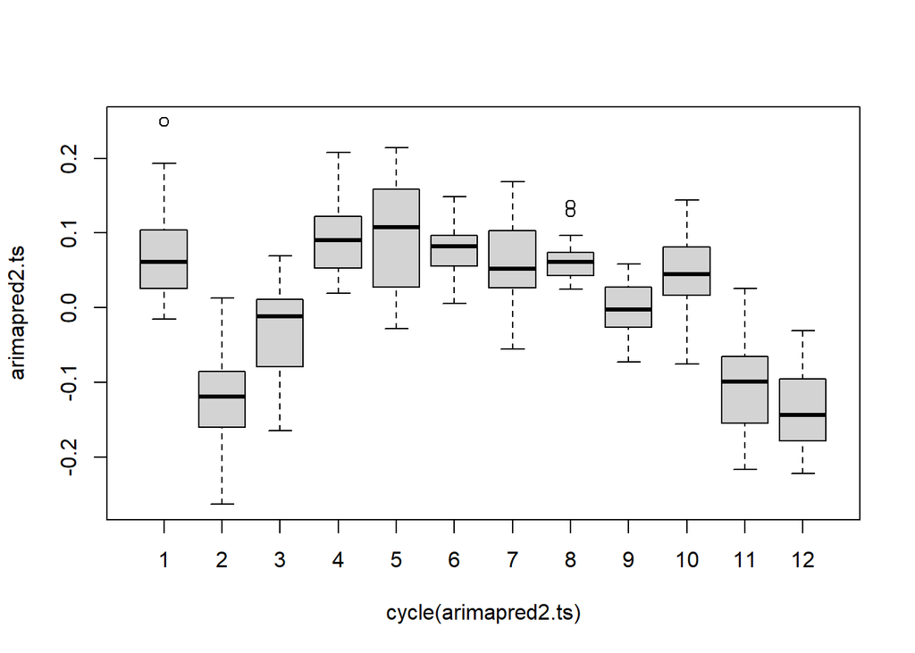

```r
arimapred2.ts<-ts(arimapred2,start=c(1990,1),freq=12)
boxplot(arimapred2.ts~cycle(arimapred2.ts))
```

**DYNAMIC ESTIMATES**

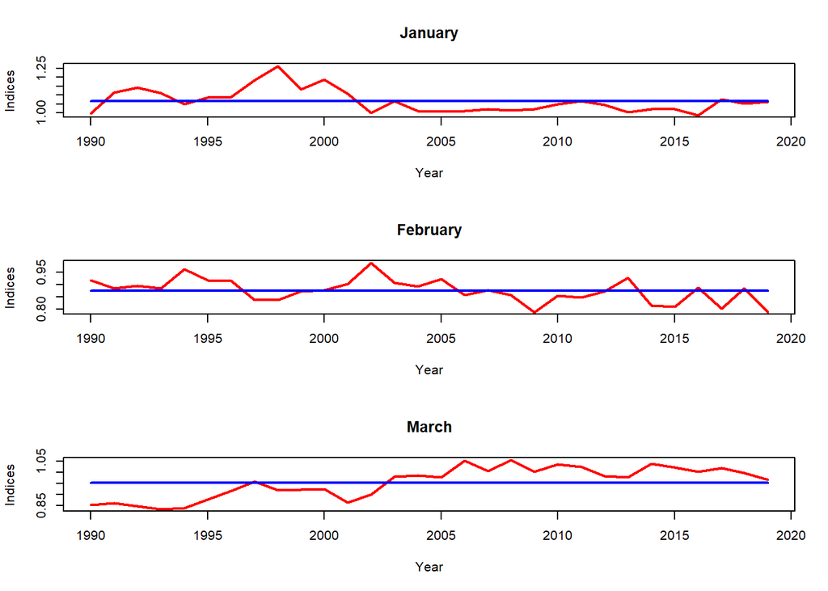

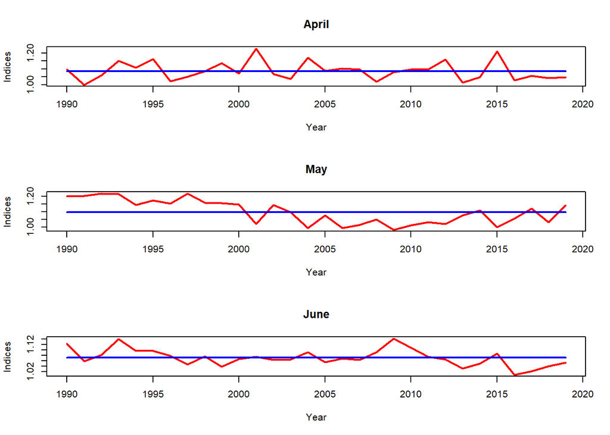

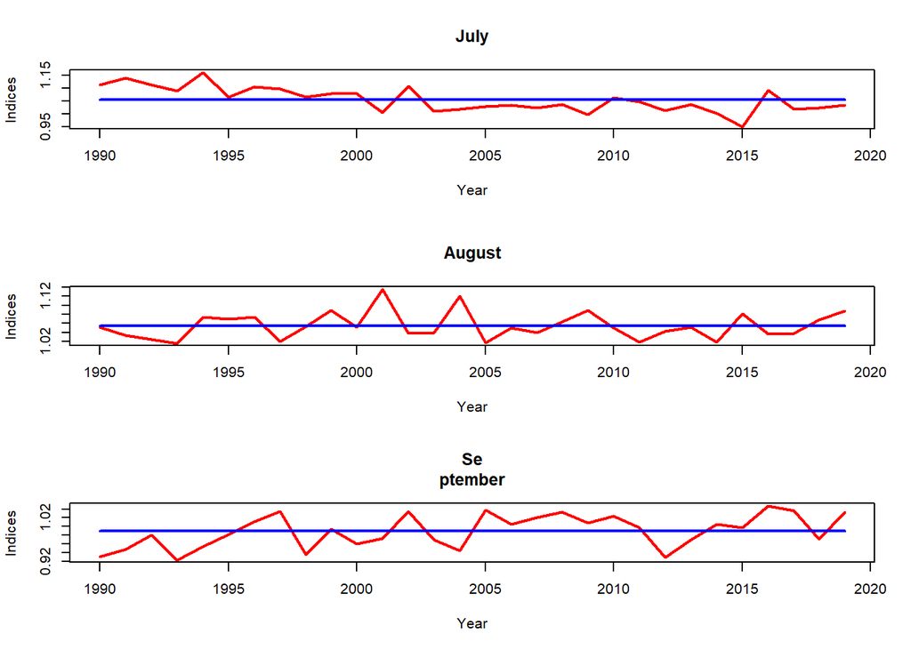

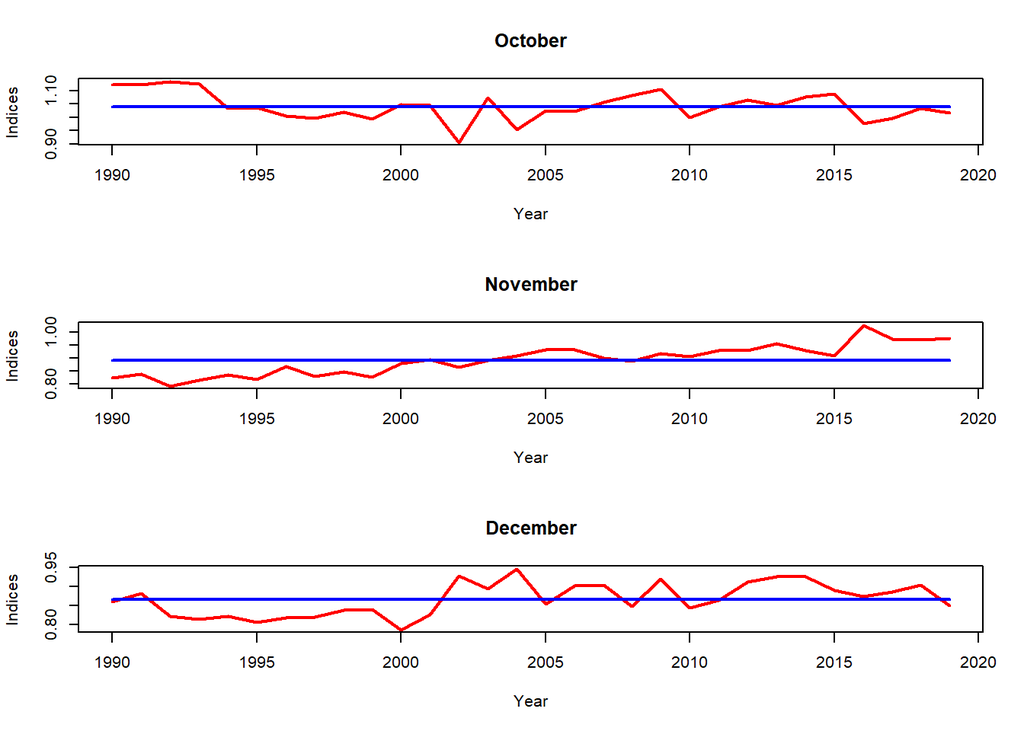

```r
y<-arimapred2
seasm<-matrix(rep(0,360),ncol=30)
j<--11
for(i in 1:30){
j<-j+12;j1<-j+11
seasm[,i]<-exp(y[j:j1]-mean(y[j:j1]))
}
year<-seq(1990,2019)
seas2m<-matrix(rep(seas2_indices,30),ncol=30)
name<-
c("January","February","March","April","May","June","July","August","Se
ptember","October","November","December")
par(mfrow=c(3,1))
for(i in 1:12){
plot(year,seasm[i,],xlab="Year",ylab="Indices",main=name[i],type="l",lwd=2,col="red")
lines(year,seas2m[i,],lty=1,lwd=2,col="blue")
}
```

Residual Analysis

**Discussion:**

The ARIMA model produced reduction to white noise.

**Residuals vs. Time Plot** - The residuals vs. time plot shows a flat residuals across time, suggesting that trend has been sufficiently captured. We also do not see fluctuations which indicate the presence of seasonality, suggesting that seasonality has also been captured by our mode.

**Normal Quantile Plot** - The majority of residuals fall on the normal quantile plot line, which suggest that we cannot reject the null hypothesis that the residuals are normally distributed.

**ACF / PACF plots** - The ACF and PACF plots indicate no remaining autocorrelation structures in the model.

**Residual Spectral Density** - The spectral density plot shows that the distance between the highest and lowest peak of the spectral density graph is less than twice the upper half of the blue measurement line above the notch, therefore we can conclude that the model has been reduced to white noise. Also, the plot indicates no significant seasonal or calendar effect within the residuals, as indicated by the lack of prominence in the blue and red dashed lines in the graph.

**Bartlett’s B test** - Bartlett’s test shows a P-value of 1, a clear indication that the model has been reduced to white noise.

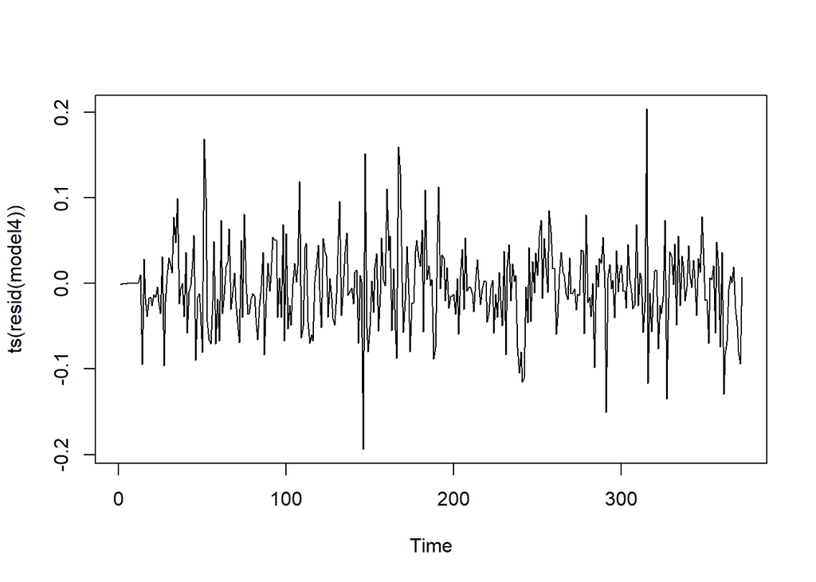

```r
plot(ts(resid(model4)))
```

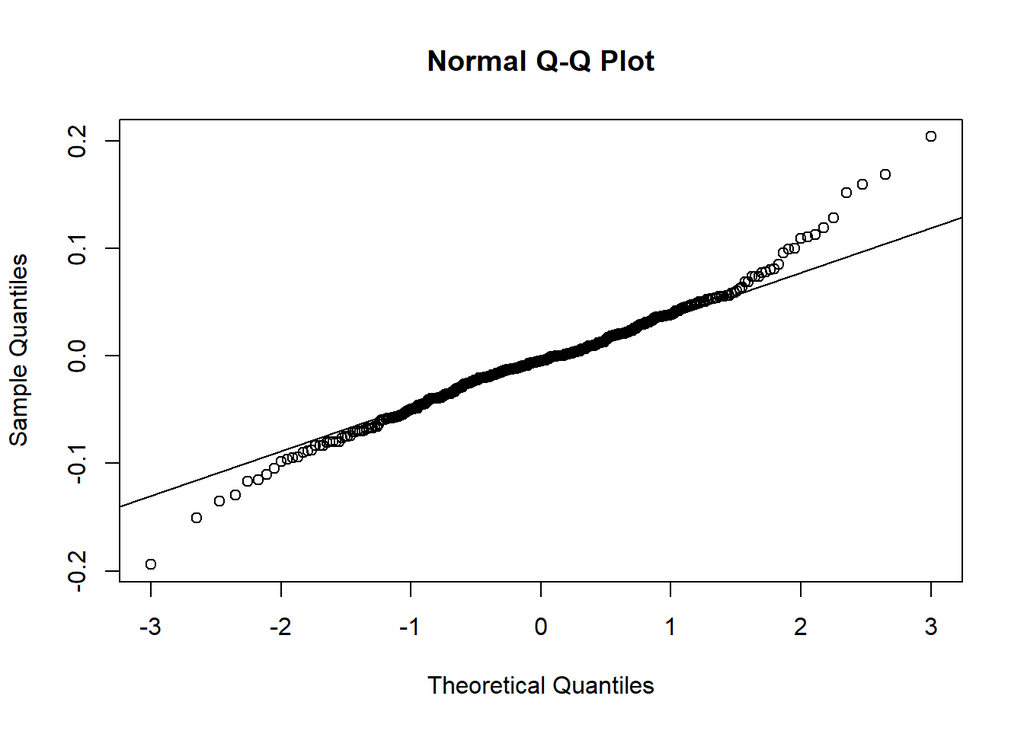

```r
qqnorm(resid(model4))
qqline(resid(model4))
```

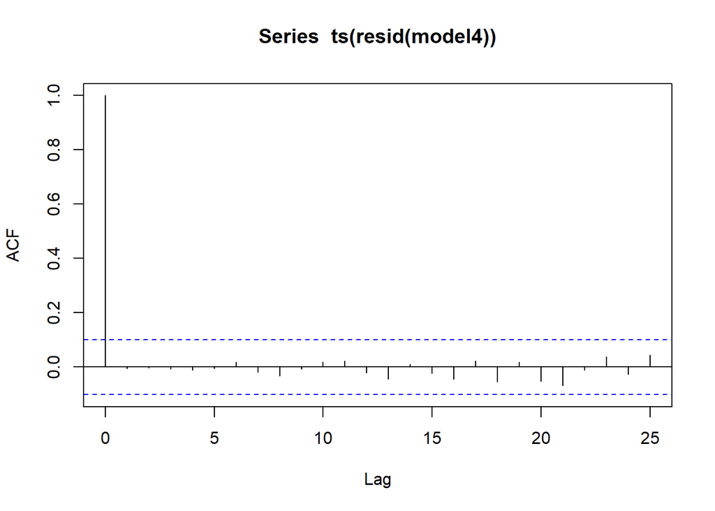

```r
acf(ts(resid(model4)))
```

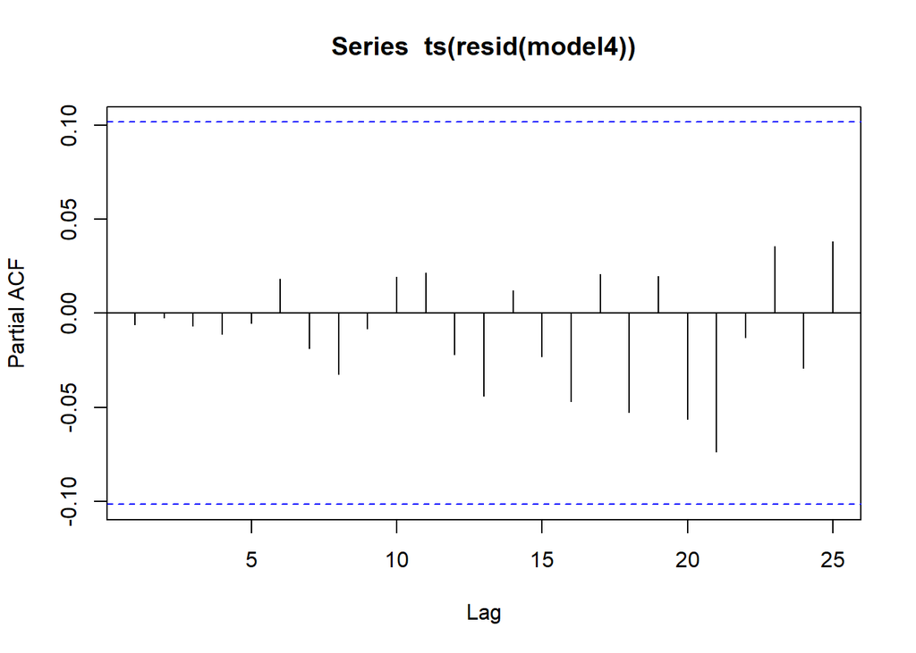

```r
pacf(ts(resid(model4)))
```

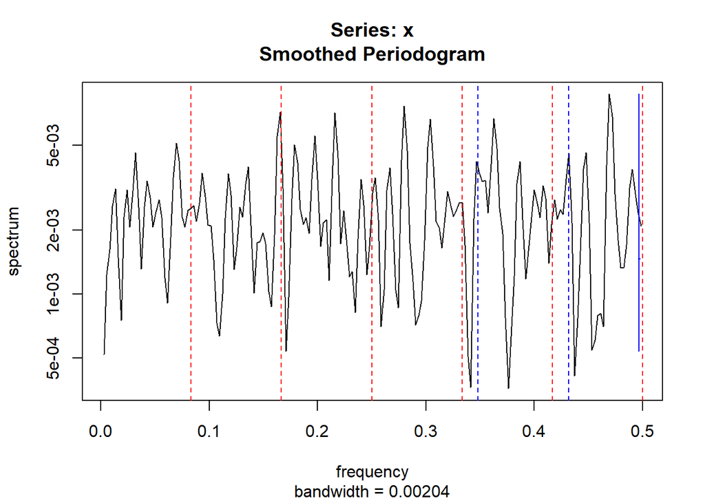

```r
spectrum(resid(model4), span=3)
abline(v=c(1/12,2/12,3/12,4/12,5/12,6/12),col="red",lty=2)
abline(v=c(0.348,0.432),col="blue",lty=2)
```

```r
bartlettB.test(ts(resid(model4)))
```

```
##
##  Bartlett B Test for white noise
##
## data:
## = 0.30137, p-value = 1
```